# Slide_Deck_Nick_Van_Wilderode slides

## Who uses our bikes at what times of the day?

Analyzing the subscribers user type, we see two peaks, one in the morning around 8:00 and one in the evening around 17:00. The Subscribers data tends to indicate they use our bikes as a tool to go and come from work.

Checking the Customer user type, we see that there isn't really a peak, it's more a curve, and the highest point is around 17:00. This suggests the usage is more for leasure and not tied to specific times as it's spread out more evenly.

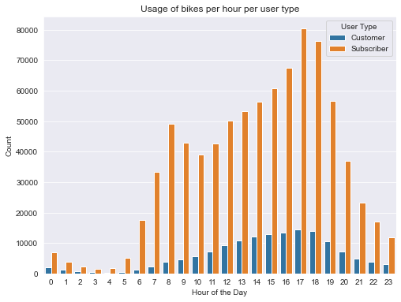

## Does this differ per day?

The heatmaps on the top showing our customer type shows the peak being on the weekend overall.  
The bottom one , for the subscribers, shows that our peaks are in the weekdays and also at the same times, morning and evening.(Rush hour)  
The different patterns between the two is rather obvious, both still enjoying the occasional bike ride on the weekend.

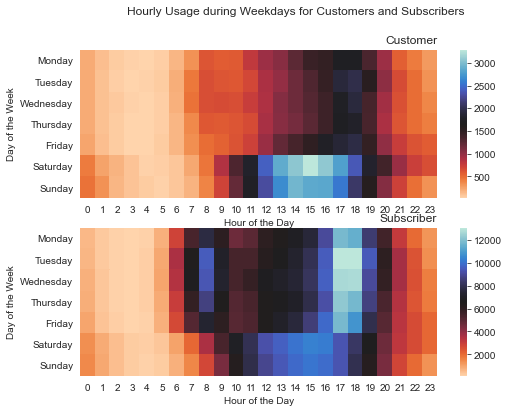

## In what weather are Customers and Subscribers most likely to ride a bike?

Interestingly, it seems that Customers have a preference in temperature. The hotter it is, the more likely they are to hire a bike.

On the Subscribers front, which we said were anual members, and tend to use the bike to go to and from work, they seem to mind less about temperature, as seen by the wider distribution.

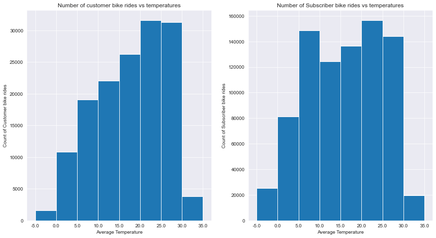

However, remember that the data of customers is a lot smaller. Next we'll see a graph to visualize both.

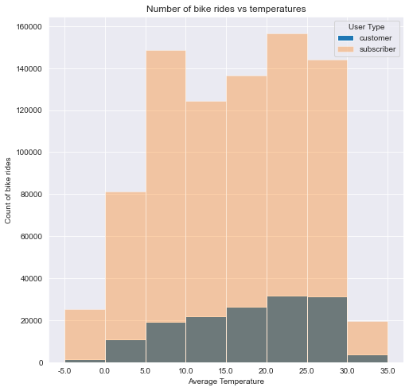

## And how long are they likely to ride a bike, depending on the weather?

We can see that they Customers ride longer overall than the subscribers, however, we do see that for the Subscriber group, the trips lenght increases considerably if the weather is nicer.

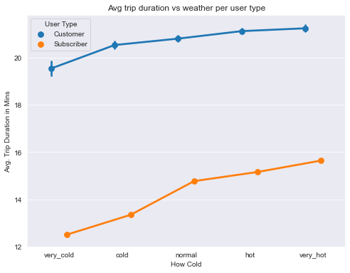